# [Financial Evaluation and Strategy: Corporate Finance](https://www.coursera.org/learn/corporate-finance/home/welcome) : Module 1

[Improving Business Finances and Operations Specialization](https://www.coursera.org/specializations/business-operations) by University of Illinois at Urbana-Champaign

[®γσ, Eng Lian Hu](http://englianhu.wordpress.com) 白戸則道®

2016-07-16

# 1. Introduction

- Section 1.1 Overview
- Section 1.2 Review criteria
- Section 1.3 Instructions
- Section 1.4 Reminders
  - Section 1.4.1 Using the Forums
  - Section 1.4.2 Honor Code

## 1.1 Overview

The purpose of this assignment is to give you the opportunity to apply the concepts you have learned in this module and to discuss some of the key ideas of the module in your own words. Follow the instructions provided and respond to each question. This a required activity for this module. The activity is peer reviewed, so after you submit your responses, you will review submissions by fellow learners in the course.

## 1.2 Review criteria

For *Assignment #1*, you will be responsible for evaluating the submissions of THREE of your peers. Before evaluating, please see the video I prepared with my discussion of the answers to *Assignment #1*.

*Assignment #1* is worth 100 points total. Points are only given for correct/reasonable answers in the manner specified below, incorrect/unreasonable answers get zero points. Points should be allocated as follows:

**Question 1**

- 10 points for a reasonable answer that is based on the arguments that we discussed in the lectures
- 5 points for an incomplete answer or a correct answer that is too long (longer than 1 paragraph)

**Question 2**

- 10 points for correctly identifying the package that is most likely to lead to shareholder value maximization and a reasonable explanation based on the arguments we discussed in the lectures
- 5 points for choosing the wrong compensation package but justifying the choice with a reasonable argument, or for a correct answer that is too long (longer than 1 paragraph)
- 2 points for correctly identifying the package but including no explanation

**Question 3**

- 10 points for the correct liquidity ratios for all years and both companies
- 5 points for an answer that is partially correct, for example not calculating the ratios for all years, or making a mistake on one of the ratios.

**Question 4**

- 10 points for the correct leverage ratios for both companies
- 5 points for an answer that is partially correct, for example not calculating all the leverage ratios, or making a mistake on one of the ratios.

**Question 5**

- 10 points for the correct profitability ratios for all years and both companies
- 5 points for an answer that is partially correct, for example not calculating the ratios for all years, or making a mistake on one of the ratios.

**Question 6**

- 10 points for the correct cash profitability ratios for all years and both companies
- 5 points for an answer that is partially correct, for example not calculating the ratios for all years, or making a mistake on one of the ratios.

**Question 7**

- 10 points for the correct analysis of the cash flow statement for both companies
- 5 points for an answer that is partially correct, for example making a mistake on the analysis of investment cash flows

**Question 8**

- 10 points for the correct valuation ratios for both companies
- 5 points for an answer that is partially correct, for example not calculating all the valuation ratios, or making a mistake on one of the ratios.

**Question 9**

- 20 points for a well justified comparison of both companies that is based on the results of questions 3 to 8
- 10 points for a reasonable but incomplete answer, for example not discussing one of the aspects such as valuation or profitability.

**Recommendations for Fair Peer Review:**

- For questions that require calculations only, the score should be based on whether or not the answer provided is correct.
- For subjective questions, the score should not be based on whether or not you agree with the answer, rather on whether the answer is complete and well-supported.
- Both content and organization are important components of a response. Good writing is confident and clearly focused with relevant details to enrich the content. Good writing also follows instructions, such as word limits, and offers requested information.
- A clear and concise answer is preferable to a long response that lacks coherence. Focus should be on content; try not to unduly penalize responses for spelling or grammar.

## 1.3 Instructions

There are multiple steps to this assignment.

First, you will submit your answers to each of the 9 questions based on the information in the Assignment Details section. Enter your answers directly in the spaces provided in the My submission tab. You may save a draft of your work as you go, and you can come back later to continue working on your draft. When you are finished working, click the Preview button, verify your identity, and then Submit the assignment. Please answer each question fully and concisely.

Then, you will evaluate the submissions of at least THREE of your peers based on the instructions provided. You may begin giving feedback to other students as soon as you submit your assignment, click the Review peers tab to begin. Feel free to provide additional reviews beyond the three required!

Assignment 1 is described in *Video Lesson 1-10*, you should watch this video before doing the assignment.

[video not shown]

For questions 3-9 you will need data from the [Nike Inc](https://github.com/englianhu/Coursera-Improving-Business-Finances-and-Operations/blob/master/4%20Financial%20Evaluation%20and%20Strategy%20-%20Corporate%20Finance/data/NIKE%20Inc%20NYSE%20NKE%20Financials.xls) and V.F. Corporation spreadsheets.

| NA. | NA..1 | NA..2 | NA..3 | NA..4 | NA..5 | NA..6 | NA..7 | NA..8 |
| --- | --- | --- | --- | --- | --- | --- | --- | --- |
| NIKE, Inc. (NYSE:NKE) > Financials > Key Stats |  |  |  |  |  |  |  |  |
| In Millions of the trading currency, except per share items. | Currency: | Trading Currency |  | Conversion: | Today's Spot Rate |  |  |  |
|  | Order: | Latest on Right |  | Units: | S&P Capital IQ (Default) |  |  |  |
|  | Decimals: | Capital IQ (Default) |  | Dilution: | Basic |  |  |  |
| Key Financials¹ |  |  |  |  |  |  |  |  |
| For the Fiscal Period Ending | 12 monthsMay-31-2011A | 12 monthsMay-31-2012A | 12 monthsMay-31-2013A | 12 monthsMay-31-2014A | 12 monthsMay-31-2015A | 12 monthsMay-31-2016E | 12 monthsMay-31-2017E | 12 monthsMay-31-2018E |
| Currency | USD | USD | USD | USD | USD | USD | USD | USD |
| Total Revenue | 20117.000000 | 23331.000000 | 25313.000000 | 27799.000000 | 30601.000000 | 32558.087560 | 35482.521000 | 39239.117580 |
| Growth Over Prior Year | 0.058009 | 0.159765 | 0.084951 | 0.098210 | 0.100794 | 0.063955 | 0.089822 | 0.105872 |
| Gross Profit | 9202.000000 | 10148.000000 | 11034.000000 | 12446.000000 | 14067.000000 | - | - | - |
| Margin % | 0.457424 | 0.434957 | 0.435902 | 0.447713 | 0.459690 | 0.464990 | 0.470622 | 0.470743 |
| EBITDA | 3189.000000 | 3465.000000 | 3740.000000 | 4266.000000 | 4824.000000 | 5299.712460 | 6026.049150 | 6818.166570 |
| Margin % | 0.158522 | 0.148514 | 0.147750 | 0.153458 | 0.157641 | 0.162777 | 0.169831 | 0.173759 |
| EBIT | 2841.000000 | 3069.000000 | 3238.000000 | 3680.000000 | 4175.000000 | 4623.881250 | 5294.537240 | 6018.518450 |
| Margin % | 0.141223 | 0.131541 | 0.127918 | 0.132378 | 0.136433 | 0.142019 | 0.149215 | 0.153381 |
| Earnings from Cont. Ops. | 2172.000000 | 2257.000000 | 2451.000000 | 2693.000000 | 3273.000000 | - | - | - |
| Margin % | 0.107968 | 0.096738 | 0.096827 | 0.096873 | 0.106957 | - | - | - |
| Net Income | 2133.000000 | 2211.000000 | 2472.000000 | 2693.000000 | 3273.000000 | 3621.513590 | 4016.566500 | 4547.318440 |
| Margin % | 0.106029 | 0.094766 | 0.097657 | 0.096873 | 0.106957 | 0.111232 | 0.113198 | 0.115887 |
| Diluted EPS Excl. Extra Items³ | 2.240000 | 2.400000 | 2.680000 | 2.970000 | 3.700000 | 4.177970 | 4.728030 | 5.500120 |
| Growth Over Prior Year | 0.160621 | 0.071428 | 0.116666 | 0.108208 | 0.245791 | 0.129181 | 0.131657 | 0.163301 |
| ¹All results are taken from the most recently filed statement for each period. When there has been more than one, earlier filings can be viewed on the individual statement pages. |  |  |  |  |  |  |  |  |
| ³All forward period figures are consensus mean estimates provided by the brokers and may not be on a comparable basis as financials. |  |  |  |  |  |  |  |  |
| Growth rates for forward periods are calculated against prior period estimates or actual pro forma results as disclosed on the Estimates Consensus page. |  |  |  |  |  |  |  |  |
| Current Capitalization (Millions of USD) |  |  |  |  |  |  |  |  |
| Currency | USD |  |  |  |  |  |  |  |
| Share Price as of Jul-27-2015 | 111.730000 |  |  |  |  |  |  |  |
| Shares Out. | 855.384053 |  |  |  |  |  |  |  |
| Market Capitalization** | 95572.060241 |  |  |  |  |  |  |  |
| Class B Common Stock Shares Out | 677.926177 |  |  |  |  |  |  |  |
| * Class B Common Stock Share Price | 111.730000 |  |  |  |  |  |  |  |
| = Class B Common Stock Market Capitalization | 75744.691756 |  |  |  |  |  |  |  |
| + Class A Common Stock Shares Out | 177.457876 |  |  |  |  |  |  |  |
| * Class A Common Stock Share Price | 111.730000 |  |  |  |  |  |  |  |
| = Class A Common Stock Market Capitalization | 19827.368485 |  |  |  |  |  |  |  |
| - Cash & Short Term Investments | 6002.000000 |  |  |  |  |  |  |  |
| + Total Debt | 1338.000000 |  |  |  |  |  |  |  |
| + Pref. Equity | - |  |  |  |  |  |  |  |
| + Total Minority Interest | - |  |  |  |  |  |  |  |
| = Total Enterprise Value (TEV) | 90908.060241 |  |  |  |  |  |  |  |
| Book Value of Common Equity | 12707.000000 |  |  |  |  |  |  |  |
| + Pref. Equity | - |  |  |  |  |  |  |  |
| + Total Minority Interest | - |  |  |  |  |  |  |  |
| + Total Debt | 1338.000000 |  |  |  |  |  |  |  |
| = Total Capital | 14045.000000 |  |  |  |  |  |  |  |

| NA. | NA..1 | NA..2 | NA..3 | NA..4 | NA..5 | NA..6 |
| --- | --- | --- | --- | --- | --- | --- |
| NIKE, Inc. (NYSE:NKE) > Financials > Income Statement |  |  |  |  |  |  |
| In Millions of the reported currency, except per share items. | Template: | Standard |  | Restatement: | Latest Filings |  |
|  | Period Type: | Annual |  | Order: | Latest on Right |  |
|  | Currency: | Reported Currency |  | Conversion: | Today's Spot Rate |  |
|  | Units: | S&P Capital IQ (Default) |  | Decimals: | Capital IQ (Default) |  |
|  | Source: | Capital IQ & Proprietary Data |  |  |  |  |
| Income Statement |  |  |  |  |  |  |
| For the Fiscal Period Ending | Restated12 monthsMay-31-2010 | Reclassified12 monthsMay-31-2011 | Restated12 monthsMay-31-2012 | Restated12 monthsMay-31-2013 | 12 monthsMay-31-2014 | 12 monthsMay-31-2015 |
| Currency | USD | USD | USD | USD | USD | USD |
| Revenue | 19014.000000 | 20117.000000 | 23331.000000 | 25313.000000 | 27799.000000 | 30601.000000 |
| Other Revenue | - | - | - | - | - | - |
| Total Revenue | 19014.000000 | 20117.000000 | 23331.000000 | 25313.000000 | 27799.000000 | 30601.000000 |
| Cost Of Goods Sold | 10214.000000 | 10915.000000 | 13183.000000 | 14279.000000 | 15353.000000 | 16534.000000 |
| Gross Profit | 8800.000000 | 9202.000000 | 10148.000000 | 11034.000000 | 12446.000000 | 14067.000000 |
| Selling General & Admin Exp. | 6326.000000 | 6361.000000 | 7079.000000 | 7796.000000 | 8766.000000 | 9892.000000 |
| R & D Exp. | - | - | - | - | - | - |
| Depreciation & Amort. | - | - | - | - | - | - |
| Other Operating Expense/(Income) | - | - | - | - | - | - |
| Other Operating Exp., Total | 6326.000000 | 6361.000000 | 7079.000000 | 7796.000000 | 8766.000000 | 9892.000000 |
| Operating Income | 2474.000000 | 2841.000000 | 3069.000000 | 3238.000000 | 3680.000000 | 4175.000000 |
| Interest Expense | -36.000000 | -32.000000 | -10.000000 | -5.000000 | -38.000000 | -34.000000 |
| Interest and Invest. Income | 30.000000 | 28.000000 | 6.000000 | 4.000000 | 5.000000 | 6.000000 |
| Net Interest Exp. | -6.000000 | -4.000000 | -4.000000 | -1.000000 | -33.000000 | -28.000000 |
| Currency Exchange Gains (Loss) | -35.000000 | 4.000000 | 56.000000 | 56.000000 | -139.000000 | -73.000000 |
| Other Non-Operating Inc. (Exp.) | 84.000000 | 21.000000 | -86.000000 | -37.000000 | 36.000000 | 131.000000 |
| EBT Excl. Unusual Items | 2517.000000 | 2862.000000 | 3035.000000 | 3256.000000 | 3544.000000 | 4205.000000 |
| Restructuring Charges | - | - | -24.000000 | - | - | - |
| Impairment of Goodwill | - | - | - | - | - | - |
| Other Unusual Items | - | - | - | - | - | - |
| EBT Incl. Unusual Items | 2517.000000 | 2862.000000 | 3011.000000 | 3256.000000 | 3544.000000 | 4205.000000 |
| Income Tax Expense | 610.000000 | 690.000000 | 754.000000 | 805.000000 | 851.000000 | 932.000000 |
| Earnings from Cont. Ops. | 1907.000000 | 2172.000000 | 2257.000000 | 2451.000000 | 2693.000000 | 3273.000000 |
| Earnings of Discontinued Ops. | - | -39.000000 | -46.000000 | 21.000000 | - | - |
| Extraord. Item & Account. Change | - | - | - | - | - | - |
| Net Income to Company | 1907.000000 | 2133.000000 | 2211.000000 | 2472.000000 | 2693.000000 | 3273.000000 |
| Minority Int. in Earnings | - | - | - | - | - | - |
| Net Income | 1907.000000 | 2133.000000 | 2211.000000 | 2472.000000 | 2693.000000 | 3273.000000 |

| NA. | NA..1 | NA..2 | NA..3 | NA..4 | NA..5 | NA..6 |
| --- | --- | --- | --- | --- | --- | --- |
| NIKE, Inc. (NYSE:NKE) > Financials > Balance Sheet |  |  |  |  |  |  |
| In Millions of the reported currency, except per share items. | Template: | Standard |  | Restatement: | Latest Filings |  |
|  | Period Type: | Annual |  | Order: | Latest on Right |  |
|  | Currency: | Reported Currency |  | Conversion: | Today's Spot Rate |  |
|  | Units: | S&P Capital IQ (Default) |  | Decimals: | Capital IQ (Default) |  |
|  | Source: | Capital IQ & Proprietary Data |  |  |  |  |
| Balance Sheet |  |  |  |  |  |  |
| Balance Sheet as of: | RestatedMay-31-2010 | 40694.000000 | ReclassifiedMay-31-2012 | RestatedMay-31-2013 | 41790.000000 | 42155.000000 |
| Currency | USD | USD | USD | USD | USD | USD |
| ASSETS |  |  |  |  |  |  |
| Cash And Equivalents | 3079.000000 | 1955.000000 | 2317.000000 | 3337.000000 | 2220.000000 | 3852.000000 |
| Short Term Investments | 2067.000000 | 2583.000000 | 1440.000000 | 2628.000000 | 2922.000000 | 2072.000000 |
| Trading Asset Securities | - | - | - | - | - | 78.000000 |
| Total Cash & ST Investments | 5146.000000 | 4538.000000 | 3757.000000 | 5965.000000 | 5142.000000 | 6002.000000 |
| Accounts Receivable | 2650.000000 | 3138.000000 | 3132.000000 | 3117.000000 | 3434.000000 | 3358.000000 |
| Notes Receivable | - | - | - | - | - | 150.000000 |
| Total Receivables | 2650.000000 | 3138.000000 | 3132.000000 | 3117.000000 | 3434.000000 | 3508.000000 |
| Inventory | 2041.000000 | 2715.000000 | 3222.000000 | 3484.000000 | 3947.000000 | 4337.000000 |
| Prepaid Exp. | 453.000000 | 563.000000 | 598.000000 | 557.000000 | 717.000000 | 704.000000 |
| Deferred Tax Assets, Curr. | 249.000000 | 312.000000 | 262.000000 | 308.000000 | 355.000000 | 389.000000 |
| Other Current Assets | 420.000000 | 31.000000 | 874.000000 | 199.000000 | 101.000000 | 1036.000000 |
| Total Current Assets | 10959.000000 | 11297.000000 | 11845.000000 | 13630.000000 | 13696.000000 | 15976.000000 |
| Gross Property, Plant & Equipment | 4390.000000 | 4906.000000 | 5057.000000 | 5500.000000 | 6220.000000 | 6352.000000 |
| Accumulated Depreciation | -2458.000000 | -2791.000000 | -2848.000000 | -3048.000000 | -3386.000000 | -3341.000000 |
| Net Property, Plant & Equipment | 1932.000000 | 2115.000000 | 2209.000000 | 2452.000000 | 2834.000000 | 3011.000000 |
| Long-term Investments | 15.000000 | 15.000000 | 18.000000 | 11.000000 | 6.000000 | - |
| Goodwill | 188.000000 | 205.000000 | 131.000000 | 131.000000 | 131.000000 | 131.000000 |
| Other Intangibles | 467.000000 | 487.000000 | 370.000000 | 289.000000 | 282.000000 | 281.000000 |
| Deferred Tax Assets, LT | 858.000000 | 872.000000 | 885.000000 | 953.000000 | 1619.000000 | 1676.000000 |
| Other Long-Term Assets | - | 7.000000 | 7.000000 | 79.000000 | 26.000000 | 525.000000 |
| Total Assets | 14419.000000 | 14998.000000 | 15465.000000 | 17545.000000 | 18594.000000 | 21600.000000 |
| LIABILITIES |  |  |  |  |  |  |
| Accounts Payable | 1255.000000 | 1469.000000 | 1549.000000 | 1614.000000 | 1870.000000 | 2053.000000 |
| Accrued Exp. | 1609.000000 | 1654.000000 | 1721.000000 | 1814.000000 | 2197.000000 | 2581.000000 |
| Short-term Borrowings | 139.000000 | 187.000000 | 108.000000 | 153.000000 | 227.000000 | 152.000000 |
| Curr. Port. of LT Debt | 7.000000 | 200.000000 | 49.000000 | 57.000000 | 7.000000 | 107.000000 |
| Curr. Income Taxes Payable | 59.000000 | 117.000000 | 65.000000 | 84.000000 | 432.000000 | 71.000000 |
| Other Current Liabilities | 295.000000 | 331.000000 | 390.000000 | 240.000000 | 294.000000 | 1370.000000 |
| Total Current Liabilities | 3364.000000 | 3958.000000 | 3882.000000 | 3962.000000 | 5027.000000 | 6334.000000 |
| Long-Term Debt | 446.000000 | 276.000000 | 228.000000 | 1210.000000 | 1199.000000 | 1079.000000 |
| Pension & Other Post-Retire. Benefits | - | - | - | - | 100.000000 | 98.000000 |
| Def. Tax Liability, Non-Curr. | 854.000000 | 910.000000 | 311.000000 | 339.000000 | 333.000000 | 351.000000 |
| Other Non-Current Liabilities | 1.000000 | 11.000000 | 663.000000 | 953.000000 | 1111.000000 | 1031.000000 |
| Total Liabilities | 4665.000000 | 5155.000000 | 5084.000000 | 6464.000000 | 7770.000000 | 8893.000000 |
| Common Stock | 3.000000 | 3.000000 | 3.000000 | 3.000000 | 3.000000 | 3.000000 |
| Additional Paid In Capital | 3441.000000 | 3944.000000 | 4641.000000 | 5184.000000 | 5865.000000 | 6773.000000 |
| Retained Earnings | 6095.000000 | 5801.000000 | 5588.000000 | 5620.000000 | 4871.000000 | 4685.000000 |
| Treasury Stock | - | - | - | - | - | - |
| Comprehensive Inc. and Other | 215.000000 | 95.000000 | 149.000000 | 274.000000 | 85.000000 | 1246.000000 |
| Total Common Equity | 9754.000000 | 9843.000000 | 10381.000000 | 11081.000000 | 10824.000000 | 12707.000000 |
| Total Equity | 9754.000000 | 9843.000000 | 10381.000000 | 11081.000000 | 10824.000000 | 12707.000000 |
| Total Liabilities And Equity | 14419.000000 | 14998.000000 | 15465.000000 | 17545.000000 | 18594.000000 | 21600.000000 |

| NA. | NA..1 | NA..2 | NA..3 | NA..4 | NA..5 | NA..6 |
| --- | --- | --- | --- | --- | --- | --- |
| NIKE, Inc. (NYSE:NKE) > Financials > Cash Flow |  |  |  |  |  |  |
| In Millions of the reported currency, except per share items. | Template: | Standard |  | Restatement: | Latest Filings |  |
|  | Period Type: | Annual |  | Order: | Latest on Right |  |
|  | Currency: | Reported Currency |  | Conversion: | Today's Spot Rate |  |
|  | Units: | S&P Capital IQ (Default) |  | Decimals: | Capital IQ (Default) |  |
|  | Source: | Capital IQ & Proprietary Data |  |  |  |  |
| Cash Flow |  |  |  |  |  |  |
| For the Fiscal Period Ending | Restated12 monthsMay-31-2010 | 12 monthsMay-31-2011 | Restated12 monthsMay-31-2012 | Restated12 monthsMay-31-2013 | Restated12 monthsMay-31-2014 | 12 monthsMay-31-2015 |
| Currency | USD | USD | USD | USD | USD | USD |
| Net Income | 1907.000000 | 2133.000000 | 2211.000000 | 2472.000000 | 2693.000000 | 3273.000000 |
| Depreciation & Amort. | 324.000000 | 335.000000 | 373.000000 | 438.000000 | 518.000000 | 606.000000 |
| Amort. of Goodwill and Intangibles | 14.000000 | 13.000000 | 23.000000 | 64.000000 | 68.000000 | 43.000000 |
| Depreciation & Amort., Total | 338.000000 | 348.000000 | 396.000000 | 502.000000 | 586.000000 | 649.000000 |
| (Gain) Loss From Sale Of Assets | - | - | - | -124.000000 | - | - |
| Stock-Based Compensation | 159.000000 | 105.000000 | 130.000000 | 174.000000 | 177.000000 | 191.000000 |
| Other Operating Activities | 66.000000 | -66.000000 | -59.000000 | 86.000000 | 45.000000 | 311.000000 |
| Change in Acc. Receivable | 182.000000 | -273.000000 | -323.000000 | 142.000000 | -298.000000 | -216.000000 |
| Change In Inventories | 285.000000 | -551.000000 | -815.000000 | -219.000000 | -505.000000 | -621.000000 |
| Change in Acc. Payable | 297.000000 | 151.000000 | 425.000000 | 27.000000 | 525.000000 | 1237.000000 |
| Change in Other Net Operating Assets | -70.000000 | -35.000000 | -141.000000 | -28.000000 | -210.000000 | -144.000000 |
| Cash from Ops. | 3164.000000 | 1812.000000 | 1824.000000 | 3032.000000 | 3013.000000 | 4680.000000 |
| Capital Expenditure | -335.000000 | -432.000000 | -563.000000 | -598.000000 | -880.000000 | -963.000000 |
| Sale of Property, Plant, and Equipment | 10.000000 | 1.000000 | 2.000000 | 14.000000 | 3.000000 | 3.000000 |
| Cash Acquisitions | - | - | - | - | - | - |
| Divestitures | - | - | - | - | - | - |
| Invest. in Marketable & Equity Securt. | -937.000000 | -537.000000 | 1139.000000 | -1140.000000 | -328.000000 | 935.000000 |
| Net (Inc.) Dec. in Loans Originated/Sold | - | - | - | - | - | - |
| Other Investing Activities | -6.000000 | -53.000000 | 8.000000 | 784.000000 | -2.000000 | -150.000000 |
| Cash from Investing | -1268.000000 | -1021.000000 | 586.000000 | -940.000000 | -1207.000000 | -175.000000 |
| Short Term Debt Issued | - | 41.000000 | - | 10.000000 | 75.000000 | - |
| Long-Term Debt Issued | - | - | - | 986.000000 | - | - |
| Total Debt Issued | - | 41.000000 | - | 996.000000 | 75.000000 | - |
| Short Term Debt Repaid | -205.000000 | - | -47.000000 | - | - | -63.000000 |
| Long-Term Debt Repaid | -32.000000 | -8.000000 | -203.000000 | -49.000000 | -77.000000 | -26.000000 |
| Total Debt Repaid | -237.000000 | -8.000000 | -250.000000 | -49.000000 | -77.000000 | -89.000000 |
| Issuance of Common Stock | 364.000000 | 345.000000 | 468.000000 | 313.000000 | 383.000000 | 514.000000 |
| Repurchase of Common Stock | -741.000000 | -1859.000000 | -1814.000000 | -1674.000000 | -2628.000000 | -2534.000000 |
| Common Dividends Paid | -505.000000 | -555.000000 | -619.000000 | -703.000000 | -799.000000 | -899.000000 |
| Total Dividends Paid | -505.000000 | -555.000000 | -619.000000 | -703.000000 | -799.000000 | -899.000000 |
| Special Dividend Paid | - | - | - | - | - | - |
| Other Financing Activities | 58.000000 | 64.000000 | 115.000000 | 72.000000 | 132.000000 | 218.000000 |
| Cash from Financing | -1061.000000 | -1972.000000 | -2100.000000 | -1045.000000 | -2914.000000 | -2790.000000 |
| Foreign Exchange Rate Adj. | -47.000000 | 57.000000 | 67.000000 | 36.000000 | -9.000000 | -83.000000 |
| Net Change in Cash | 788.000000 | -1124.000000 | 377.000000 | 1083.000000 | -1117.000000 | 1632.000000 |

*table 1.3.1: Financial statement of stock counter NKE.*

| NA. | NA..1 | NA..2 | NA..3 | NA..4 | NA..5 | NA..6 | NA..7 | NA..8 |
| --- | --- | --- | --- | --- | --- | --- | --- | --- |
| V.F. Corporation (NYSE:VFC) > Financials > Key Stats |  |  |  |  |  |  |  |  |
| In Millions of the trading currency, except per share items. | Currency: | Trading Currency |  | Conversion: | Today's Spot Rate |  |  |  |
|  | Order: | Latest on Right |  | Units: | S&P Capital IQ (Default) |  |  |  |
|  | Decimals: | Capital IQ (Default) |  | Dilution: | Basic |  |  |  |
| Key Financials¹ |  |  |  |  |  |  |  |  |
| For the Fiscal Period Ending | 12 monthsDec-31-2011A | 12 monthsDec-29-2012A | 12 monthsDec-28-2013A | 12 monthsJan-03-2015A | LTM²Press Release12 monthsJul-04-2015A | 12 monthsDec-31-2015E | 12 monthsDec-31-2016E | 12 monthsDec-31-2017E |
| Currency | USD | USD | USD | USD | USD | USD | USD | USD |
| Total Revenue | 9459.232000 | 10879.855000 | 11419.648000 | 12282.161000 | 12450.468000 | 12725.686910 | 13805.698210 | 14887.623270 |
| Growth Over Prior Year | 0.228058 | 0.150183 | 0.049613 | 0.075528 | 0.057793 | 0.036111 | 0.084869 | 0.078368 |
| Gross Profit | 4330.630000 | 5061.975000 | 5488.179000 | 5993.971000 | 6061.295000 | - | - | - |
| Margin % | 0.457820 | 0.465261 | 0.480590 | 0.488022 | 0.486832 | 0.489926 | 0.494727 | 0.498381 |
| EBITDA | 1477.026000 | 1734.023000 | 1911.120000 | 2108.969000 | 2104.897000 | 2195.142570 | 2432.391050 | 2647.782740 |
| Margin % | 0.156146 | 0.159379 | 0.167353 | 0.171709 | 0.169061 | 0.172497 | 0.176187 | 0.177851 |
| EBIT | 1278.291000 | 1496.067000 | 1657.847000 | 1834.086000 | 1831.950000 | 1905.166360 | 2135.048540 | 2367.944050 |
| Margin % | 0.135136 | 0.137507 | 0.145174 | 0.149329 | 0.147139 | 0.149710 | 0.154650 | 0.159055 |
| Earnings from Cont. Ops. | 890.393000 | 1086.138000 | 1210.119000 | 1047.505000 | 1052.150000 | - | - | - |
| Margin % | 0.094129 | 0.099830 | 0.105968 | 0.085286 | 0.084506 | - | - | - |
| Net Income | 888.089000 | 1085.999000 | 1210.119000 | 1047.505000 | 1052.150000 | 1396.420130 | 1569.901190 | 1748.954710 |
| Margin % | 0.093885 | 0.099817 | 0.105968 | 0.085286 | 0.084506 | 0.109732 | 0.113714 | 0.117477 |
| Diluted EPS Excl. Extra Items³ | 2.000000 | 2.430000 | 2.710000 | 2.380000 | 2.413200 | 3.236750 | 3.702640 | 4.246140 |
| Growth Over Prior Year | 0.544401 | 0.215000 | 0.115226 | -0.121772 | -0.148644 | 0.050893 | 0.143938 | 0.146787 |
| ¹All results are taken from the most recently filed statement for each period. When there has been more than one, earlier filings can be viewed on the individual statement pages. |  |  |  |  |  |  |  |  |
| ²Growth rates for the LTM period are calculated against the LTM period ending 12 months before. |  |  |  |  |  |  |  |  |
| ³All forward period figures are consensus mean estimates provided by the brokers and may not be on a comparable basis as financials. |  |  |  |  |  |  |  |  |
| Growth rates for forward periods are calculated against prior period estimates or actual pro forma results as disclosed on the Estimates Consensus page. |  |  |  |  |  |  |  |  |
| Current Capitalization (Millions of USD) |  |  |  |  |  |  |  |  |
| Currency | USD |  |  |  |  |  |  |  |
| Share Price as of Jul-23-2015 | 74.670000 |  |  |  |  |  |  |  |
| Shares Out. | 424.975000 |  |  |  |  |  |  |  |
| Market Capitalization** | 31732.883250 |  |  |  |  |  |  |  |
| - Cash & Short Term Investments | 659.770000 |  |  |  |  |  |  |  |
| + Total Debt | 2584.035000 |  |  |  |  |  |  |  |
| + Pref. Equity | - |  |  |  |  |  |  |  |
| + Total Minority Interest | - |  |  |  |  |  |  |  |
| = Total Enterprise Value (TEV) | 33657.148250 |  |  |  |  |  |  |  |
| Book Value of Common Equity | 4963.795000 |  |  |  |  |  |  |  |
| + Pref. Equity | - |  |  |  |  |  |  |  |
| + Total Minority Interest | - |  |  |  |  |  |  |  |
| + Total Debt | 2584.035000 |  |  |  |  |  |  |  |
| = Total Capital | 7547.830000 |  |  |  |  |  |  |  |

| NA. | NA..1 | NA..2 | NA..3 | NA..4 | NA..5 | NA..6 |
| --- | --- | --- | --- | --- | --- | --- |
| V.F. Corporation (NYSE:VFC) > Financials > Income Statement |  |  |  |  |  |  |
| In Millions of the reported currency, except per share items. | Template: | Standard |  | Restatement: | Latest Filings |  |
|  | Period Type: | Annual |  | Order: | Latest on Right |  |
|  | Currency: | Reported Currency |  | Conversion: | Today's Spot Rate |  |
|  | Units: | S&P Capital IQ (Default) |  | Decimals: | Capital IQ (Default) |  |
|  | Source: | Capital IQ & Proprietary Data |  |  |  |  |
| Income Statement |  |  |  |  |  |  |
| For the Fiscal Period Ending | 12 monthsJan-01-2011 | Reclassified12 monthsDec-31-2011 | 12 monthsDec-29-2012 | 12 monthsDec-28-2013 | 12 monthsJan-03-2015 | LTMPress Release12 monthsJul-04-2015 |
| Currency | USD | USD | USD | USD | USD | USD |
| Revenue | 7702.589000 | 9459.232000 | 10879.855000 | 11419.648000 | 12282.161000 | 12450.468000 |
| Other Revenue | - | - | - | - | - | - |
| Total Revenue | 7702.589000 | 9459.232000 | 10879.855000 | 11419.648000 | 12282.161000 | 12450.468000 |
| Cost Of Goods Sold | 4105.201000 | 5128.602000 | 5817.880000 | 5931.469000 | 6288.190000 | 6389.173000 |
| Gross Profit | 3597.388000 | 4330.630000 | 5061.975000 | 5488.179000 | 5993.971000 | 6061.295000 |
| Selling General & Admin Exp. | 2574.790000 | 3052.339000 | 3565.908000 | 3830.332000 | 4159.885000 | 4229.345000 |
| R & D Exp. | - | - | - | - | - | - |
| Depreciation & Amort. | - | - | - | - | - | - |
| Other Operating Expense/(Income) | - | - | - | - | - | - |
| Other Operating Exp., Total | 2574.790000 | 3052.339000 | 3565.908000 | 3830.332000 | 4159.885000 | 4229.345000 |
| Operating Income | 1022.598000 | 1278.291000 | 1496.067000 | 1657.847000 | 1834.086000 | 1831.950000 |
| Interest Expense | -77.700000 | -77.600000 | -93.600000 | -84.800000 | -86.700000 | -88.500000 |
| Interest and Invest. Income | 2.336000 | 4.778000 | 3.353000 | 4.141000 | 6.911000 | 6.911000 |
| Net Interest Exp. | -75.400000 | -72.800000 | -90.300000 | -80.600000 | -79.800000 | -81.600000 |
| Currency Exchange Gains (Loss) | -0.100000 | 1.395000 | 3.547000 | -2.200000 | -1.900000 | -1.900000 |
| Other Non-Operating Inc. (Exp.) | -0.800000 | -8.600000 | 1.313000 | -1.800000 | -3.600000 | 0.450000 |
| EBT Excl. Unusual Items | 946.250000 | 1198.243000 | 1410.675000 | 1573.190000 | 1748.728000 | 1748.936000 |
| Merger & Related Restruct. Charges | - | -33.500000 | -30.800000 | -10.700000 | - | - |
| Impairment of Goodwill | -201.700000 | - | - | - | -142.400000 | -142.400000 |
| Gain (Loss) On Sale Of Invest. | 5.700000 | - | - | - | - | - |
| Gain (Loss) On Sale Of Assets | - | - | 42.000000 | - | - | - |
| Asset Writedown | - | - | - | - | -254.000000 | -254.000000 |
| Other Unusual Items | - | - | - | - | - | - |
| EBT Incl. Unusual Items | 750.212000 | 1164.743000 | 1421.875000 | 1562.490000 | 1352.366000 | 1352.574000 |
| Income Tax Expense | 176.700000 | 274.350000 | 335.737000 | 352.371000 | 304.861000 | 300.424000 |
| Earnings from Cont. Ops. | 573.512000 | 890.393000 | 1086.138000 | 1210.119000 | 1047.505000 | 1052.150000 |
| Earnings of Discontinued Ops. | - | - | - | - | - | - |
| Extraord. Item & Account. Change | - | - | - | - | - | - |
| Net Income to Company | 573.512000 | 890.393000 | 1086.138000 | 1210.119000 | 1047.505000 | 1052.150000 |
| Minority Int. in Earnings | -2.200000 | -2.300000 | -0.100000 | - | - | - |
| Net Income | 571.362000 | 888.089000 | 1085.999000 | 1210.119000 | 1047.505000 | 1052.150000 |
|  | - | - | - | - | - | - |

| NA. | NA..1 | NA..2 | NA..3 | NA..4 | NA..5 | NA..6 |
| --- | --- | --- | --- | --- | --- | --- |
| V.F. Corporation (NYSE:VFC) > Financials > Balance Sheet |  |  |  |  |  |  |
| In Millions of the reported currency, except per share items. | Template: | Standard |  | Restatement: | Latest Filings |  |
|  | Period Type: | Annual |  | Order: | Latest on Right |  |
|  | Currency: | Reported Currency |  | Conversion: | Today's Spot Rate |  |
|  | Units: | S&P Capital IQ (Default) |  | Decimals: | Capital IQ (Default) |  |
|  | Source: | Capital IQ & Proprietary Data |  |  |  |  |
| Balance Sheet |  |  |  |  |  |  |
| Balance Sheet as of: | 40544.000000 | 40908.000000 | 41272.000000 | 41636.000000 | 42007.000000 | Press ReleaseJul-04-2015 |
| Currency | USD | USD | USD | USD | USD | USD |
| ASSETS |  |  |  |  |  |  |
| Cash And Equivalents | 792.239000 | 341.228000 | 597.461000 | 776.403000 | 971.895000 | 659.770000 |
| Total Cash & ST Investments | 792.239000 | 341.228000 | 597.461000 | 776.403000 | 971.895000 | 659.770000 |
| Accounts Receivable | 773.083000 | 1120.246000 | 1222.345000 | 1360.443000 | 1276.224000 | 1200.241000 |
| Total Receivables | 773.083000 | 1120.246000 | 1222.345000 | 1360.443000 | 1276.224000 | 1200.241000 |
| Inventory | 1070.694000 | 1453.645000 | 1354.158000 | 1399.062000 | 1482.804000 | 1746.418000 |
| Deferred Tax Assets, Curr. | 68.220000 | 106.717000 | 140.515000 | 169.321000 | 154.285000 | - |
| Other Current Assets | 121.824000 | 166.108000 | 135.104000 | 177.753000 | 300.646000 | 600.061000 |
| Total Current Assets | 2826.060000 | 3187.944000 | 3449.583000 | 3882.982000 | 4185.854000 | 4206.490000 |
| Gross Property, Plant & Equipment | 1663.299000 | 1830.039000 | 1983.417000 | 2169.980000 | 2269.123000 | - |
| Accumulated Depreciation | -1060.400000 | -1092.600000 | -1155.200000 | -1237.200000 | -1326.900000 | - |
| Net Property, Plant & Equipment | 602.908000 | 737.451000 | 828.218000 | 932.792000 | 942.181000 | 964.373000 |
| Long-term Investments | 23.292000 | 15.177000 | 15.067000 | 17.514000 | 15.666000 | - |
| Goodwill | 1166.638000 | 2023.460000 | 2009.757000 | 2021.750000 | 1824.956000 | 1796.769000 |
| Other Intangibles | 1534.483000 | 3008.652000 | 2987.944000 | 3080.838000 | 2603.821000 | 2296.200000 |
| Deferred Tax Assets, LT | 38.523000 | 29.304000 | 27.170000 | 16.537000 | 20.252000 | - |
| Deferred Charges, LT | 33.328000 | 48.483000 | 47.184000 | 54.305000 | 54.855000 | - |
| Other Long-Term Assets | 232.324000 | 262.655000 | 268.098000 | 308.725000 | 332.555000 | 641.672000 |
| Total Assets | 6457.556000 | 9313.126000 | 9633.021000 | 10315.443000 | 9980.140000 | 9905.504000 |
| LIABILITIES |  |  |  |  |  |  |
| Accounts Payable | 510.998000 | 637.116000 | 562.638000 | 638.732000 | 690.842000 | 503.753000 |
| Accrued Exp. | 503.994000 | 661.697000 | 667.131000 | 752.881000 | 757.131000 | 780.286000 |
| Short-term Borrowings | 36.576000 | 281.686000 | 12.559000 | 18.810000 | 21.822000 | 1158.516000 |
| Curr. Port. of LT Debt | 2.737000 | 2.744000 | 402.873000 | 5.167000 | 0.213000 | 13.275000 |
| Curr. Port. of Cap. Leases | - | - | - | - | 3.762000 | - |
| Curr. Income Taxes Payable | 10.499000 | 17.284000 | 44.592000 | 91.635000 | 98.860000 | - |
| Def. Tax Liability, Curr. | 6.897000 | 9.740000 | 6.601000 | 9.367000 | 6.176000 | - |
| Other Current Liabilities | 37.774000 | 55.765000 | 35.818000 | 51.409000 | 41.435000 | - |
| Total Current Liabilities | 1109.475000 | 1666.032000 | 1732.212000 | 1568.001000 | 1620.241000 | 2455.830000 |
| Long-Term Debt | 935.882000 | 1831.781000 | 1429.166000 | 1426.829000 | 1402.435000 | 1412.244000 |
| Capital Leases | - | - | - | - | 21.146000 | - |
| Pension & Other Post-Retire. Benefits | 201.499000 | 394.753000 | 474.175000 | 214.431000 | 364.304000 | - |
| Def. Tax Liability, Non-Curr. | 7.936000 | 415.852000 | 366.804000 | 452.506000 | 348.394000 | - |
| Other Non-Current Liabilities | 341.445000 | 479.533000 | 505.039000 | 576.638000 | 592.738000 | 1073.635000 |
| Total Liabilities | 2596.237000 | 4787.951000 | 4507.396000 | 4238.405000 | 4349.258000 | 4941.709000 |
| Common Stock | 107.938000 | 110.557000 | 110.205000 | 110.078000 | 108.215000 | 4963.795000 |
| Additional Paid In Capital | 2081.367000 | 2316.107000 | 2527.868000 | 2746.590000 | 2993.186000 | - |
| Retained Earnings | 1940.508000 | 2520.804000 | 2941.447000 | 3432.090000 | 3231.753000 | - |
| Treasury Stock | - | - | - | - | - | - |
| Comprehensive Inc. and Other | -268.600000 | -421.500000 | -453.900000 | -211.700000 | -702.300000 | - |
| Total Common Equity | 3861.219000 | 4525.991000 | 5125.625000 | 6077.038000 | 5630.882000 | 4963.795000 |
| Minority Interest | 0.100000 | -0.800000 | - | - | - | - |
| Total Equity | 3861.319000 | 4525.175000 | 5125.625000 | 6077.038000 | 5630.882000 | 4963.795000 |
| Total Liabilities And Equity | 6457.556000 | 9313.126000 | 9633.021000 | 10315.443000 | 9980.140000 | 9905.504000 |

| NA. | NA..1 | NA..2 | NA..3 | NA..4 | NA..5 | NA..6 |
| --- | --- | --- | --- | --- | --- | --- |
| V.F. Corporation (NYSE:VFC) > Financials > Cash Flow |  |  |  |  |  |  |
| In Millions of the reported currency, except per share items. | Template: | Standard |  | Restatement: | Latest Filings |  |
|  | Period Type: | Annual |  | Order: | Latest on Right |  |
|  | Currency: | Reported Currency |  | Conversion: | Today's Spot Rate |  |
|  | Units: | S&P Capital IQ (Default) |  | Decimals: | Capital IQ (Default) |  |
|  | Source: | Capital IQ & Proprietary Data |  |  |  |  |
| Cash Flow |  |  |  |  |  |  |
| For the Fiscal Period Ending | 12 monthsJan-01-2011 | 12 monthsDec-31-2011 | 12 monthsDec-29-2012 | 12 monthsDec-28-2013 | 12 monthsJan-03-2015 | LTMPress Release12 monthsJul-04-2015 |
| Currency | USD | USD | USD | USD | USD | USD |
| Net Income | 571.362000 | 888.089000 | 1085.999000 | 1210.119000 | 1047.505000 | 1052.150000 |
| Depreciation & Amort. | 134.023000 | 157.027000 | 190.027000 | 207.486000 | 232.822000 | 230.886000 |
| Amort. of Goodwill and Intangibles | 39.373000 | 41.708000 | 47.929000 | 45.787000 | 42.061000 | 42.061000 |
| Depreciation & Amort., Total | 173.396000 | 198.735000 | 237.956000 | 253.273000 | 274.883000 | 272.947000 |
| (Gain) Loss From Sale Of Assets | - | - | -44.500000 | - | - | - |
| Asset Writedown & Restructuring Costs | 201.738000 | - | - | - | 396.362000 | 396.362000 |
| Stock-Based Compensation | 63.538000 | 76.739000 | 92.814000 | 87.118000 | 104.313000 | 104.313000 |
| Provision & Write-off of Bad debts | 7.441000 | 12.490000 | 19.264000 | 15.756000 | -2.200000 | -2.200000 |
| Other Operating Activities | -106.600000 | 70.448000 | -81.800000 | -26.200000 | -83.800000 | -360.900000 |
| Change in Acc. Receivable | -13.000000 | -154.500000 | -111.600000 | -155.100000 | 0.854000 | 0.854000 |
| Change In Inventories | -114.300000 | -7.500000 | 87.620000 | -47.200000 | -130.500000 | -130.500000 |
| Change in Acc. Payable | 140.470000 | -32.900000 | -74.300000 | 75.073000 | 69.807000 | 69.807000 |
| Change in Inc. Taxes | -14.600000 | 16.009000 | 26.213000 | 16.628000 | -44.100000 | -44.100000 |
| Change in Other Net Operating Assets | 91.863000 | 13.755000 | 37.271000 | 76.533000 | 64.603000 | -167.000000 |
| Cash from Ops. | 1001.282000 | 1081.371000 | 1275.000000 | 1506.041000 | 1697.629000 | 1191.596000 |
| Capital Expenditure | -111.600000 | -170.900000 | -251.900000 | -271.200000 | -234.100000 | -263.700000 |
| Cash Acquisitions | -38.300000 | -2207.100000 | -1.800000 | - | - | - |
| Divestitures | - | - | 72.519000 | - | - | - |
| Sale (Purchase) of Intangible assets | -13.600000 | -78.200000 | -30.900000 | -54.000000 | -67.900000 | -55.400000 |
| Invest. in Marketable & Equity Securt. | - | - | - | - | - | - |
| Net (Inc.) Dec. in Loans Originated/Sold | - | - | - | - | - | - |
| Other Investing Activities | -16.900000 | -3.800000 | -8.200000 | -25.100000 | -27.200000 | -4.900000 |
| Cash from Investing | -180.500000 | -2460.000000 | -220.300000 | -350.300000 | -329.300000 | -324.000000 |
| Short Term Debt Issued | - | 250.824000 | - | 9.032000 | 4.761000 | - |
| Long-Term Debt Issued | - | 898.450000 | - | - | - | - |
| Total Debt Issued | - | 1149.274000 | - | 9.032000 | 4.761000 | 581.549000 |
| Short Term Debt Repaid | -9.700000 | - | -269.000000 | - | - | - |
| Long-Term Debt Repaid | -203.100000 | -2.700000 | -2.800000 | -404.900000 | -4.800000 | - |
| Total Debt Repaid | -212.800000 | -2.700000 | -271.800000 | -404.900000 | -4.800000 | -4.300000 |
| Issuance of Common Stock | 137.732000 | 134.012000 | 62.770000 | 48.029000 | 34.869000 | 28.821000 |
| Repurchase of Common Stock | -411.800000 | -7.400000 | -307.300000 | -282.000000 | -727.800000 | -731.800000 |
| Common Dividends Paid | -264.300000 | -285.700000 | -333.200000 | -402.100000 | -478.900000 | -478.900000 |
| Common and/or Pref. Dividends Paid | - | - | - | - | - | -43.900000 |
| Total Dividends Paid | -264.300000 | -285.700000 | -333.200000 | -402.100000 | -478.900000 | -522.800000 |
| Special Dividend Paid | - | - | - | - | - | - |
| Other Financing Activities | 8.359000 | -75.200000 | 47.012000 | 48.140000 | 64.437000 | 62.962000 |
| Cash from Financing | -742.800000 | 912.245000 | -802.500000 | -983.800000 | -1107.400000 | -585.500000 |
| Foreign Exchange Rate Adj. | -17.300000 | 15.406000 | 4.039000 | 7.005000 | -65.500000 | -98.200000 |
| Net Change in Cash | 60.690000 | -451.000000 | 256.233000 | 178.942000 | 195.492000 | 183.879000 |

*table 1.3.2: Financial statement of stock counter VFC.*

The discussion of the assignment solution is provided in Video Lesson 1-11. Do the assignment on your own first, before viewing the assignment discussion video! Please view the assignment discussion video before completing the review of your peers.

## 1.4 Reminders

### 1.4.1 Using the Forums

Your fellow students are a great resource, and we encourage you to sharpen your ideas against them in the forums. You can post your arguments in the Module 1 Forum and receive feedback before submitting this assignment. Additionally, make sure to pay attention to posts from the instructors, which are intended to spur conversation on topics related to the week’s theme.

### 1.4.2 Honor Code

Please remember that you have agreed to the Honor Code, and your submission should be entirely yours. Our definition of plagiarism follows from standard literature: passing off someone else’s work as your own, whether from your peers or Wikipedia. If you need to quote material, remember to cite your source, for example: “But, as expressed by Spinoza, all things excellent are as difficult as they are rare (Baruch Spinoza,”Ethica" source: thinkexist.com)."

# 2. Case Study

- Section 2.1 2.1 Question 1
- Section 2.2 2.2 Question 2
- Section 2.3 2.3 Question 3
- Section 2.4 2.4 Question 4
- Section 2.5 2.5 Question 5
- Section 2.6 2.6 Question 6
- Section 2.7 2.7 Question 7
- Section 2.8 2.8 Question 8
- Section 2.9 2.9 Question 9

## 2.1 Question 1

```
  Explain why maximizing current stockholder wealth is a reasonable objective for the corporation (1 paragraph maximum).
```

- Stockholder/shareholder invest the money on a corperate and expect the management growth the corperate to generate profit.
- Due to the income of the corperate is generated by staffs since shareholder cannot spend thier time to oversee the operation of a corperate, therefore they hire/appoint a team of management to lead or manage the corperate.
- Shareholders hold the right to sake the management team anytime if the management unable hit the target or vision expected by shareholders.
- A corperate especially a public listed company need to acquire/inject fund from the stock market, the shareholders expected the company can growth and willing to invest. The performance of the management will be evaluate by the shareholders as well. Management level can be dictator only who hold a majority portion of shares and contribute a lot to the corperate. For example, Steve Jobs, Larry Ellison, Bill Gates, Mark Zuckerberg are the soul of their own corperate.

## 2.2 Question 2

[output not shown]

- **Package 1**: Normally high salary paid to board of directors can stimulate them to growth the business group since high revnecue and also profit made by the group, the board of directors will also get higher paid.
- However, there has pro and con since fixed salary will induce low quality and inefficiency of the board of directors becasue the salary might not affected by the revenue and also profit made by the group.
- Normally a small and medium conservative busissness group do not take the high risk will offer the package 1. Some companies with a stable and certain business income might also offer package 1.
- **Package 2**: A large and also some aggresive busissness group normally will offer a certain amount of stock of the company to the board of directors. The board of director will be stimulated and more loyal to growth the business group.
- However the stress given by shareholders to the board of directors will also be high accordingly. The risk of saking is also high since the shareholders provide the rumination pay and expect the board of directors to join the big family, stand with shareholders (same objective and profit sharing from the stocks awarded by shareholders) and struggle and sincerely to growth the business group. You can refer to below articles:
  - [Ladbrokes appoints Jim Mullen as Chief Executive Officer](http://www.ladbrokesplc.com/media/press-releases/2015/20-03-2015.aspx)
  - [Ladbrokes CEO Richard Glynn to step down next year](http://www.cityam.com/1417591987/ladbrokes-ceo-richard-glynn-step-down-next-year)
  - [Ladbrokes shareholders rebel over executive pay](http://www.ft.com/fastft/2016/05/05/ladbrokes-shareholders-rebel-over-executive-pay/)
  - [The Max Attacks: This month I’d fire the CEO of William Hill](http://www.londonlovesbusiness.com/business-news/management/the-max-attacks-this-month-id-fire-the-ceo-of-william-hill/2446.article)
  - [William Hill faces shareholder showdown over CEO’s £1.2m ‘gift’](http://www.telegraph.co.uk/finance/newsbysector/retailandconsumer/leisure/9247960/William-Hill-faces-shareholder-showdown-over-CEOs-1.2m-gift.html)
- **Comparison**: package 1 might efficient within short-term period (might be 3 to 5 years or 8 to 10 years) due to high paid, however package 2 might probably get loyalty of board of directors who will stay and growth with the business group long life (might probably 30 to 50 years).
- For example, not only Ladbrokes, William Hill prefer package 2… Maxbet, SBOBet and Crown offer package 2 to the management level and most of them work more than 10 to 20 years compare to William Hill and Ladbrokes.

## 2.3 Question 3

[output not shown]

| Balance.sheet | Formula | May2013 | May2014 | May2015 |
| --- | --- | --- | --- | --- |
| Total Cash & ST Investments |  | 5965.000000 | 5142.000000 | 6.002000e+03 |
| Total Receivables |  | 3117.000000 | 3434.000000 | 3.508000e+03 |
| Total Current Assets |  | 13630.000000 | 13696.000000 | 1.597600e+04 |
| Total Current Liabilities |  | 3962.000000 | 5027.000000 | 6.334000e+03 |
| Current Ratio | Total Current Assets/Total Current Liabilities | 3.440182 | 2.724488 | 2.522261e+00 |
| Quick Ratio | (Total Cash & ST Investments + Total Receivables) / Total Current Liabilities | 2.292277 | 1.705988 | 1.501421e+00 |
| Cash Ratio | Total Cash & ST Investments / Total Current Liabilities | 1.505553 | 1.022876 | 9.475845e-01 |

*table 2.3.1: Current ratio of stock NKE.*

| Balance.sheet | Formula | Dec2013 | Jan2015 | Jul2015 |
| --- | --- | --- | --- | --- |
| Total Cash & ST Investments |  | 776.4000000 | 971.9000000 | 659.8000000 |
| Total Receivables |  | 1360.4000000 | 1276.2000000 | 1200.2000000 |
| Total Current Assets |  | 3883.0000000 | 4185.9000000 | 4206.5000000 |
| Total Current Liabilities |  | 1568.0000000 | 1620.2000000 | 2455.8000000 |
| Current Ratio | Total Current Assets/Total Current Liabilities | 2.4764031 | 2.5835699 | 1.7128838 |
| Quick Ratio | (Total Cash & ST Investments + Total Receivables) / Total Current Liabilities | 1.3627551 | 1.3875447 | 0.7573907 |
| Cash Ratio | Total Cash & ST Investments / Total Current Liabilities | 0.4951531 | 0.5998642 | 0.2686701 |

*table 2.3.2: Current ratio of stock VFC.*

**What is the ‘Current Ratio’?**

The current ratio is a liquidity ratio that measures a company’s ability to pay short-term and long-term obligations. To gauge this ability, the current ratio considers the current total assets of a company (both liquid and illiquid) relative to that company’s current total liabilities.

The formula for calculating a company’s current ratio, then, is:

$$Current\ Ratio = Current\ Assets / Current\ Liabilities$$

The current ratio is called “current” because, unlike some other liquidity ratios, it incorporates all current assets and liabilities.

You can refer to [What is the ‘Current Ratio’](http://www.investopedia.com/terms/c/currentratio.asp) for further details.

**What is the ‘Quick Ratio’?**

The quick ratio is an indicator of a company’s short-term liquidity. The quick ratio measures a company’s ability to meet its short-term obligations with its most liquid assets. For this reason, the ratio excludes inventories from current assets, and is calculated as follows:

$Quick\ ratio = (current\ assets – inventories) / current\ liabilities$, or $Quick\ ratio = (cash\ and\ equivalents + marketable\ securities + accounts receivable) / current\ liabilities$

The quick ratio measures the dollar amount of liquid assets available for each dollar of current liabilities. Thus, a quick ratio of 1.5 means that a company has $1.50 of liquid assets available to cover each $1 of current liabilities. The higher the quick ratio, the better the company’s liquidity position. Also known as the “acid-test ratio” or “quick assets ratio.”

Read more: [Quick Ratio Definition | Investopedia](http://www.investopedia.com/terms/q/quickratio.asp#ixzz4EOkPt2pF)

**Liquidity Measurement Ratios: Cash Ratio**

The cash ratio is an indicator of a company’s liquidity that further refines both the current ratio and the quick ratio by measuring the amount of cash, cash equivalents or invested funds there are in current assets to cover current liabilities…

Very few companies will have enough cash and cash equivalents to fully cover current liabilities, which isn’t necessarily a bad thing, so don’t focus on this ratio being above 1:1…

- Liquidity Measurement Ratios: Introduction
- Liquidity Measurement Ratios: Current Ratio
- Liquidity Measurement Ratios: Quick Ratio
- Liquidity Measurement Ratios: Cash Ratio
- Liquidity Measurement Ratios: Cash Conversion Cycle

Read more: [Liquidity Measurement Ratios: Cash Ratio | Investopedia](http://www.investopedia.com/university/ratios/liquidity-measurement/ratio3.asp#ixzz4EOpfKU5b)

**Comparison**

## 2.4 Question 4

```
  Compute the main balance sheet leverage ratios for both Nike and V.F.Corporation (Debt/(Debt + Equity), and Liabilities/Assets). You only need to do this using the most recently available data so as to reflect the current valuation of the companies.
```

$$\frac{Debt}{Debt + Market\ Value\ of\ Assets} \cdots equation\ 2.4.1$$
$$\frac{Total\ Liabilities}{Market\ Value\ of\ Assets} \cdots equation\ 2.4.2$$
$$Market\ Value\ of\ Assets = Market\ Value\ of\ Equity + Total\ Liabilities \cdots equation\ 2.4.3$$

| Currency | USD |
| --- | --- |
| Current Capitalization (Millions of USD) |  |
| Currency | USD |
| Share Price as of Jul-27-2015 | 111.730000 |
| Shares Out. | 855.384053 |
| Market Capitalization** | 95572.060241 |
| Class B Common Stock Shares Out | 677.926177 |
| * Class B Common Stock Share Price | 111.730000 |
| = Class B Common Stock Market Capitalization | 75744.691756 |
| + Class A Common Stock Shares Out | 177.457876 |
| * Class A Common Stock Share Price | 111.730000 |
| = Class A Common Stock Market Capitalization | 19827.368485 |
| - Cash & Short Term Investments | 6002.000000 |
| + Total Debt | 1338.000000 |
| + Pref. Equity | - |
| + Total Minority Interest | - |
| = Total Enterprise Value (TEV) | 90908.060241 |
| Book Value of Common Equity | 12707.000000 |
| + Pref. Equity | - |
| + Total Minority Interest | - |
| + Total Debt | 1338.000000 |
| = Total Capital | 14045.000000 |

*table 2.4.1A: Key stats of stock counter NKE.*

| Balance.sheet | May-31-2010 | May-31-2011 | May-31-2012 | May-31-2013 | May-31-2014 | May-31-2015 |
| --- | --- | --- | --- | --- | --- | --- |
| Total Assets | 14419.000000 | 14998.000000 | 15465.000000 | 17545.000000 | 18594.000000 | 21600.000000 |
| Total Liabilities | 4665.000000 | 5155.000000 | 5084.000000 | 6464.000000 | 7770.000000 | 8893.000000 |
| Total Equity | 9754.000000 | 9843.000000 | 10381.000000 | 11081.000000 | 10824.000000 | 12707.000000 |
| Total Liabilities And Equity | 14419.000000 | 14998.000000 | 15465.000000 | 17545.000000 | 18594.000000 | 21600.000000 |

*table 2.4.1B: Main balance sheet of stock counter NKE.*

- **Market Value of Equity**: $95572.06 (Jul-27-2015)
- **Market Value of Assets**: $104465.06 (Jul-27-2015)

| Currency | USD |
| --- | --- |
| Current Capitalization (Millions of USD) |  |
| Currency | USD |
| Share Price as of Jul-23-2015 | 74.670000 |
| Shares Out. | 424.975000 |
| Market Capitalization** | 31732.883250 |
| - Cash & Short Term Investments | 659.770000 |
| + Total Debt | 2584.035000 |
| + Pref. Equity | - |
| + Total Minority Interest | - |
| = Total Enterprise Value (TEV) | 33657.148250 |
| Book Value of Common Equity | 4963.795000 |
| + Pref. Equity | - |
| + Total Minority Interest | - |
| + Total Debt | 2584.035000 |
| = Total Capital | 7547.830000 |

*table 2.4.2A: Key stats of stock counter VFC.*

| Balance.sheet | Jan-01-2011 | Dec-31-2011 | Dec-29-2012 | Dec-28-2013 | Jan-03-2015 | Jul-04-2015 |
| --- | --- | --- | --- | --- | --- | --- |
| Total Assets | 6457.556000 | 9313.126000 | 9633.021000 | 10315.443000 | 9980.140000 | 9905.504000 |
| Total Liabilities | 2596.237000 | 4787.951000 | 4507.396000 | 4238.405000 | 4349.258000 | 4941.709000 |
| Total Equity | 3861.319000 | 4525.175000 | 5125.625000 | 6077.038000 | 5630.882000 | 4963.795000 |
| Total Liabilities And Equity | 6457.556000 | 9313.126000 | 9633.021000 | 10315.443000 | 9980.140000 | 9905.504000 |

- **Market Value of Equity**: $31732.88 (Jul-23-2015)
- **Market Value of Assets**: $36674.59 (Jul-23-2015)

**Understanding Leverage Ratio**

While some businesses pride themselves on being debt-free, most companies have had to borrow at one point or another to buy equipment, build new offices or cut payroll checks. For the investor, the challenge is determining whether the organization’s debt level is sustainable.

Is having debt, in and of itself, harmful? Well, yes and no. In some cases, borrowing may actually be a positive sign. Consider a company that wants to build a new plant because of increased demand for its products. It may have to take out a loan or sell bonds to pay for the construction and equipment costs, but it’s expecting future sales to more than make up for any associated borrowing costs. And because interest expenses are tax-deductible, debt can be a cheaper way to increase assets than equity.

The problem is when the use of debt, also known as leveraging, becomes excessive. With interest payments taking a large chunk out of top-line sales, a company will have less cash to fund marketing, research and development and other important investments.

Large debt loads can make businesses particularly vulnerable during an economic downturn. If the corporation struggles to make regular interest payments, investors are likely to lose confidence and bid down the share price. In more extreme cases, bankruptcy becomes a very real possibility.

For these reasons, seasoned investors take a good look at liabilities before purchasing corporate stock or bonds. As a way to quickly size up businesses in this regard, traders have developed a number of ratios that help separate healthy borrowers from those swimming in debt.

**Debt and Debt-to-Equity Ratios**

Two of the most popular calculations, the debt ratio and debt-to-equity ratio, rely on information readily available on the company’s balance sheet. To determine the debt ratio, simply divide the firm’s total liabilities by its total assets:

$$Debt\ Ratio = Total\ Liabilities / Total\ Assets \cdots equation\ 2.4.4$$

A figure of 0.5 or less is ideal. In other words, no more than half of the company’s assets should be financed by debt. In reality, many investors tolerate significantly higher ratios. Capital-intensive industries like heavy manufacturing depend more on debt than service-based firms, for example, and debt ratios in excess of 0.7 are common.

As its name implies, the debt-to-equity ratio instead compares the company’s debt to its stockholder equity. It’s calculated as follows:

$$Debt-to-equity\ Ratio = Total\ Liabilities / Stockholders'\ Equity \cdots equation\ 2.4.5$$

If you consider the basic accounting equation (Assets – Liabilities = Equity), you may realize that these two equations are really looking at the same thing. In other words, a debt ratio of 0.5 will necessarily mean a debt-to-equity ratio of 1. In both cases, a lower number indicates a company less dependent on borrowing for its operations.

While both these ratios can be useful tools, they’re not without shortcomings. For example, both calculations include short-term liabilities in the numerator. Most investors, however, are more interested in long-term debt. For this reason, some traders will substitute “total liabilities” with “long-term liabilities” when crunching the numbers.

In addition, some liabilities may not even appear on the balance sheet, and thus don’t enter into the ratio. Operating leases, commonly used by retailers, are one example. Generally Accepted Accounting Principles, or GAAP, doesn’t require companies to report these on the balance sheet, but they do show up in the footnotes. Investors who want a more accurate look at debt will want to comb through financial statements for this valuable information.

**Interest Coverage Ratio**

Perhaps the biggest limitation of the debt and debt-to-equity ratios is that they look at the total amount of borrowing, not the company’s ability to actually service its debt. Some organizations may carry what looks like a significant amount of debt, but they generate enough cash to easily handle interest payments.

Furthermore, not all corporations borrow at the same rate. A company that has never defaulted on its obligations may be able to borrow at a 3 percent interest rate, while its competitor pays a 6 percent rate.

To account for these factors, investors often use the interest coverage ratio. Rather than looking at the sum total of debt, the calculation factors in the actual cost of interest payments in relation to operating income (considered one of the best indicators of long-term profit potential). It’s determined with this straightforward formula:

$$Interest\ Coverage\ Ratio = Operating\ Income / Interest\ Expense \cdots equation\ 2.4.6$$

In this case, higher numbers are seen as favorable. In general, a ratio of 3 and above represents a strong ability to pay off debt, although here, too, the threshold varies from one industry to another.

Read more: [Understanding Leverage Ratios | Investopedia](http://www.investopedia.com/articles/investing/080113/understanding-leverage-ratios.asp#ixzz4ETp6lT6n)

**Comparison**

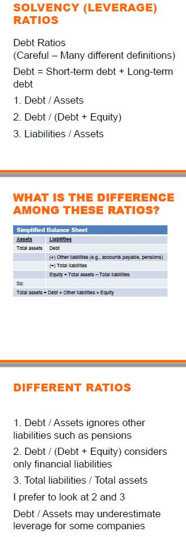

*figure 2.4.1: Solvency (leverage) ratio.*

[output not shown]

*table 2.4.3: Leverage ratios of stock counter NKE and VFC.*

We can know from above table where both companies have low leverage ratio.

## 2.5 Question 5

```
  Compute the main profitability ratios for both Nike and V.F.Corporation (Asset turnover, profit margin, and ROA). Do this for the last 3 years available.
```

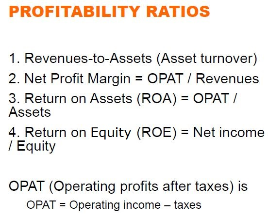

*figure 2.5.1: Profitability ratio.*

Kindly refer to [**Operations Management: Module 1: Operations Strategy Assignment 2** *by ®γσ, Eng Lian Hu 2016*](http://rpubs.com/englianhu/187414) to know about: - Asset Turnover - Operating Margin - Return of Equity

refer to reference paper 02 in 4.4 References

| Statement | May-31-2013 | May-31-2014 | May-31-2015 |
| --- | --- | --- | --- |
| Total Revenue | 25313 | 27799 | 30601 |
| Operating Income | 3238 | 3680 | 4175 |
| Income Tax Expense | 805 | 851 | 932 |
| Total Assets | 17545 | 18594 | 21600 |
| Total Equity | 11081 | 10824 | 12707 |

*table 2.5.1A: Key financial statement of NKE.*

| Statement | Dec-28-2013 | Jan-03-2015 | Jul-04-2015 |
| --- | --- | --- | --- |
| Total Revenue | 11419.648 | 12282.161 | 12450.468 |
| Operating Income | 1657.847 | 1834.086 | 1831.950 |
| Income Tax Expense | 352.371 | 304.861 | 300.424 |
| Total Assets | 10315.443 | 9980.140 | 9905.504 |
| Total Equity | 6077.038 | 5630.882 | 4963.795 |

*table 2.5.1B: Key financial statement of VFC.*

| Profitability.Ratio | May.31.2013 | May.31.2014 | May.31.2015 |
| --- | --- | --- | --- |
| Asset turnover | 1.4427472 | 1.4950522 | 1.4167130 |
| OPAT | 2433.0000000 | 2829.0000000 | 3243.0000000 |
| Net Profit Margin | 0.0961166 | 0.1017663 | 0.1059769 |
| ROA | 0.1386720 | 0.1521459 | 0.1501389 |
| ROE | 0.2922119 | 0.3399852 | 0.3285591 |

*table 2.5.2A: Profitability ratio of NKE.*

| Profitability.Ratio | Dec.28.2013 | Jan.03.2015 | Jul.04.2015 |
| --- | --- | --- | --- |
| Asset turnover | 1.1070439 | 1.2306602 | 1.2569242 |
| OPAT | 1305.4760000 | 1529.2250000 | 1531.5260000 |
| Net Profit Margin | 0.1143184 | 0.1245078 | 0.1230095 |
| ROA | 0.1265555 | 0.1532268 | 0.1546136 |
| ROE | 0.2728051 | 0.3257191 | 0.3690624 |

*table 2.5.2B: Profitability ratio of VFC.*

**Comparison**

By refer to *table 2.5.2A* and *table 2.5.2B*:

- *Asset turnover*: NKE generates more revenue from the its company asset compare to VFC.
- *Net Profit Margin*: The profit margin of VFC slightly higher than NKE.
- *ROA*: The return of assets of both companies almost same.
- *ROE*: The return on equity of both companies almost same.

## 2.6 Question 6

```
  Compute the cash profitability ratio for both Nike and V.F.Corporation. Do this for the last 3 years available.
```

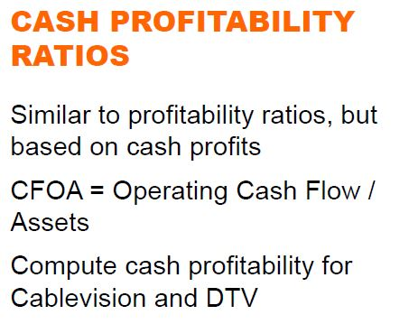

*figure 2.6.1: Cash profitability ratio.*

| Statement | May.31.2013 | May.31.2014 | May.31.2015 |
| --- | --- | --- | --- |
| Total Assets | 1.754500e+04 | 1.859400e+04 | 2.160000e+04 |
| Cash from Ops. | 3.032000e+03 | 3.013000e+03 | 4.680000e+03 |
| CFOA | 1.728128e-01 | 1.620415e-01 | 2.166667e-01 |

*table 2.6.1A: Cash profitability ratio of NKE.*

| Statement | Dec.28.2013 | Jan.03.2015 | Jul.04.2015 |
| --- | --- | --- | --- |
| Total Assets | 1.031544e+04 | 9980.1400000 | 9905.5040000 |
| Cash from Ops. | 1.506041e+03 | 1697.6290000 | 1191.5960000 |
| CFOA | 1.459987e-01 | 0.1701007 | 0.1202964 |

*table 2.6.1B: Cash profitability ratio of VFC.*

**Comparison**

From above tables, *CFOA* of both companies have no big range difference on making profit but latest year 2015 NKE has greater cash profitability ratio.

## 2.7 Question 7

```
  Analyze the cash flow statement of both Nike and V.F.Corporation in the last 3 years. Are the companies investing to grow the business? Are they raising cash from investors or are they returning cash to investors?
```

| Category | May-31-2013 | May-31-2014 | May-31-2015 |
| --- | --- | --- | --- |
| Cash from Ops. | 3032.000000 | 3013.000000 | 4680.000000 |
| Cash from Investing | -940.000000 | -1207.000000 | -175.000000 |
| Cash from Financing | -1045.000000 | -2914.000000 | -2790.000000 |
| Issuance of Common Stock | 313.000000 | 383.000000 | 514.000000 |
| Repurchase of Common Stock | -1674.000000 | -2628.000000 | -2534.000000 |
| Net Change in Cash | 1083.000000 | -1117.000000 | 1632.000000 |

*table 2.7.1A: cash flow statement of NKE.*

| Category | Dec-28-2013 | Jan-03-2015 | Jul-04-2015 |
| --- | --- | --- | --- |
| Cash from Ops. | 1506.041000 | 1697.629000 | 1191.596000 |
| Cash from Investing | -350.300000 | -329.300000 | -324.000000 |
| Cash from Financing | -983.800000 | -1107.400000 | -585.500000 |
| Issuance of Common Stock | 48.029000 | 34.869000 | 28.821000 |
| Repurchase of Common Stock | -282.000000 | -727.800000 | -731.800000 |
| Net Change in Cash | 178.942000 | 195.492000 | 183.879000 |

*table 2.7.1B: cash flow statement of VFC.*

**What is ‘Cash Flow From Operating Activities (CFO)’?**

Cash flow from operating activities (CFO) is an accounting item indicating the money a company brings in from ongoing, regular business activities, such as manufacturing and selling goods or providing a service. Cash flow from operating activities does not include long-term capital or investment costs. It does include earnings before interest and taxes plus depreciation minus taxes.

Also called operating cash flow or net cash from operating activities, it can be calculated as follows:

$$Cash\ Flow\ From\ Operating\ Activities = EBIT + Depreciation - Taxes \cdots equation\ 2.7.1$$

Read more: [Cash Flow From Operating Activities Definition | Investopedia](http://www.investopedia.com/terms/c/cash-flow-from-operating-activities.asp#ixzz4EVH82A00)

**What is ‘Cash Flow From Investing Activities’?**

Cash flow from investing activities is an item on the cash flow statement that reports the aggregate change in a company’s cash position resulting from any gains (or losses) from investments in the financial markets and operating subsidiaries and changes resulting from amounts spent on investments in capital assets such as plant and equipment.

Read more: [Cash Flow From Investing Activities Definition | Investopedia](http://www.investopedia.com/terms/c/cashflowfinvestingactivities.asp#ixzz4EVI5eQb2)

**What is ‘Cash Flow From Financing Activities’?**

A category in a company’s cash flow statement that accounts for external activities that allow a firm to raise capital and repay investors, such as issuing cash dividends, adding or changing loans or issuing more stock. Cash flow from financing activities shows investors the company’s financial strength. A company that frequently turns to new debt or equity for cash, for example, could have problems if the capital markets become less liquid.

The formula for cash flow from financing activities is as follows:

$$Cash\ Received\ from\ Issuing\ Stock\ or\ Debt - Cash\ Paid\ as\ Dividends\ and Re-Acquisition\ of\ Debt/Stock \cdots equation\ 2.7.2$$

Read more: [Cash Flow from Financing Activities Definition | Investopedia](http://www.investopedia.com/terms/c/cashflowfromfinancing.asp#ixzz4EVLShE5Y)

**Comparison**

From above tables, we observed that both companies make profit from the cash flow, while NKE had refinanced and repurchased the stock in year 2014.

- *Cash from operating activities*: positive figure means both companies making money from the business.
- *Cash from investing activities*: The negative figure might indicate the company buying assets or repurchased the stock. You can refer to *table 2.5.1A* and *table 2.5.1B* to know the assets and equity as well. Examples of negative cash flow from investing activities includes the purchase of fixed assets, the purchase of investment instruments such as stocks, and lending money. Examples of positive cash flow from investing includes the sale of fixed assets, the sale of investment instruments, and the collection of loans and insurance proceeds.
- *Cash from financing activities*: Financing activities that generate negative cash flow include spending cash to repurchase previously issued stock, to pay down debt, to pay interest on debt and to pay dividends to shareholders.

## 2.8 Question 8

```
  Compute the main valuation ratios for Nike and V.F.Corporation (Value/OPAT and Market/Book). You only need to do this using the most recently available data so as to reflect the current valuation of the companies.
```

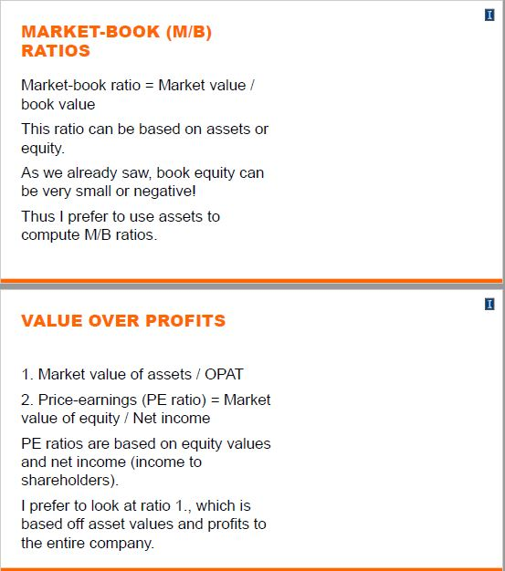

*figure 2.8.1: Valuation ratio.*

**Market Value Versus Book Value**

Understanding the difference between book value and market value is a simple yet fundamentally critical component of any attempt to analyze a company for investment. After all, when you invest in a share of stock or an entire business, you want to know you are paying a sensible price.

Book value literally means the value of the business according to its “books” or financial statements. In this case, book value is calculated from the balance sheet, and it is the difference between a company’s total assets and total liabilities. Note that this is also the term for shareholders’ equity. For example, if Company XYZ has total assets of $100 million and total liabilities of $80 million, the book value of the company is $20 million. In a very broad sense, this means that if the company sold off its assets and paid down its liabilities, the equity value or net worth of the business, would be $20 million.

Market value is the value of a company according to the stock market. Market value is calculated by multiplying a company’s shares outstanding by its current market price. If Company XYZ has 1 million shares outstanding and each share trades for $50, then the company’s market value is $50 million. Market value is most often the number analysts, newspapers and investors refer to when they mention the value of the business.

**Implications of Each**

Book value simply implies the value of the company on its books, often referred to as accounting value. It’s the accounting value once assets and liabilities have been accounted for by a company’s auditors. Whether book value is an accurate assessment of a company’s value is determined by stock market investors who buy and sell the stock. Market value has a more meaningful implication in the sense that it is the price you have to pay to own a part of the business regardless of what book value is stated.

As you can see from our fictitious example from Company XYZ above, market value and book value differ substantially. In the actual financial markets, you will find that book value and market value differ the vast majority of the time. The difference between market value and book value can depend on various factors such as the company’s industry, the nature of a company’s assets and liabilities, and the company’s specific attributes. There are three basic generalizations about the relationships between book value and market value:

- **Book Value Greater Than Market Value**: The financial market values the company for less than its stated value or net worth. When this is the case, it’s usually because the market has lost confidence in the ability of the company’s assets to generate future profits and cash flows. In other words, the market doesn’t believe that the company is worth the value on its books. Value investors often like to seek out companies in this category in hopes that the market perception turns out to be incorrect. After all, the market is giving you the opportunity to buy a business for less than its stated net worth.
- **Market Value Greater Than Book Value**: The market assigns a higher value to the company due to the earnings power of the company’s assets. Nearly all consistently profitable companies will have market values greater than book values.
- **Book Value Equals Market Value**: The market sees no compelling reason to believe the company’s assets are better or worse than what is stated on the balance sheet.

It’s important to note that on any given day, a company’s market value will fluctuate in relation to book value. The metric that tells this is known as the price-to-book ratio, or the P/B ratio:

$$P/B\ Ratio = Share\ Price/Book\ Value\ Per\ Share \cdots equation\ 2.8.1$$

(where Book Value Per Share equals shareholders’ equity divided by number of shares outstanding)

So one day, a company can have a P/B of 1, meaning that BV and MV are equal. The next day, the market price drops and the P/B ratio is less than 1, meaning market value is less than book value. The following day the market price zooms higher and creates a P/B ratio of greater than 1, meaning market value now exceeds book value. To an investor, whether the P/B ratio is 0.95, 1 or 1.1, the underlying stock trades at book value. In other words, P/B becomes more meaningful the greater the number differs from 1. To a value-seeking investor, a company that trades for a P/B ratio of 0.5 implies that the market value is one-half of the company’s stated book value. In other words, the market is selling you each $1 of net assets (net assets = assets - liabilities) for 50 cents. Everyone likes to buy things on sale, right?

Read more: [Market Value Versus Book Value | Investopedia](http://www.investopedia.com/articles/investing/110613/market-value-versus-book-value.asp#ixzz4EYbCHal3)

| Latest Year 2015 | Formula | NKE | VFC |
| --- | --- | --- | --- |
| Value / OPAT | Market Capitalization** / OPAT | 29.470262 | 20.719781 |
| Market / Book | Market Capitalization** / Book Value of Common Equity | 7.521213 | 6.392867 |

*table 2.8.1: Valuation ratio of company NKE and VFC.*

- **Market Value ÷ Operating Profits After Taxes**: these ratio consider as the investors’ prospective ratio in financial market based on every single dollar net profit. Normally a company make profit consistantly will has a ratio which more than 1. NKE has greater ratio than VFC since we can know NKE is healthier than VFC from the cash flow and other key ratios from income and balance statements.
- **Market Value ÷ Book Value**: Both companies have a ratio which greater than 1, it means investors in financial market forecast these two companies will keeping make profit. Normally a company make profit consistantly will has a ratio which more than 1. NKE has greater ratio than VFC since we can know NKE is healthier than VFC from the cash flow and other key ratios from income and balance statements.

## 2.9 Question 9

```
  Discuss the implications of your results. How do the two companies compare to each other? What have you learned from the comparison of financial ratios for these two companies? (2 paragraphs maximum)
```

# 3. Conclusion

[video not shown]

Here is the video, you can refer to the answer from the lecturer after finished the assignment. Below are some questions and understanding to the assignment.

- The **Total Liabilities / Total Assets** ratio inside *table 2.4.3* different with above answer.

  ```
  …The tools you need to understand Buffett's definition of intrinsic value go by the soporific moniker of discounted cash flow analysis. But when the richest guy in the world says it's the most important thing you can know if you want to get rich, I'll bet it's worth staying awake for…
  ```

  *quote 3.1: source taken from [Cash Flow Analysis](http://dailyreckoning.com/cash-flow-analysis/)*
- The cash flow statement is the crucial evaluation of intrinsic value prior to make investment which was quoted by [Warren Buffet](http://www.warrenbuffett.com/), I am not understand completely in *table 2.7.1A*, I need to keep up learning on interpretation of cashflow statement which applicable in real life.

  Kindly refer to [Cash Flow Analysis](http://dailyreckoning.com/cash-flow-analysis/) for further details.
  - [Warren Buffett’s Investing Style Reviewed](http://www.investopedia.com/articles/05/012705.asp)
  - [Warren Buffett: Owner Earnings vs. Free Cash Flow](http://www.valuewalk.com/2015/11/warren-buffett-owner-earnings-vs-free-cash-flow/)
  - [BUFFETT FAQ](http://buffettfaq.com/)
- The measured ratio in *table 2.8.1* different with the answer from the video. I tried to looking for some reference.

Further learning required in order to understand an applicable and realizable evaluation skills for investment in our real life in evaluation of corporates and the interpretation of **intrinsic value** from Warren Buffet.

# 4. Appendices

- Section 4.1 Documenting File Creation
- Section 4.2 Versions’ Log
- Section 4.3 Speech and Blooper
- Section 4.4 References

## 4.1 Documenting File Creation

It’s useful to record some information about how your file was created.

- File creation date: 2016-07-10
- File latest updated date: 2016-07-16
- R version 3.3.1 (2016-06-21)
- R version (short form): 3.3.1
- **rmarkdown** package version: 1.0
- [**tufte** package](https://github.com/rstudio/tufte) version: 0.2
- File version: 1.0.0
- Author Profile: [®γσ, Eng Lian Hu](https://beta.rstudioconnect.com/englianhu/ryo-eng/)
- GitHub: [Source Code](https://github.com/englianhu/Coursera-Improving-Business-Finances-and-Operations/tree/master/4%20Financial%20Evaluation%20and%20Strategy%20-%20Corporate%20Finance)
- Additional session information:

[1] “2016-07-16 20:30:05 JST” setting value  
version R version 3.3.1 (2016-06-21) system x86_64, mingw32  
ui RTerm  
language (EN)  
collate English_United States.1252  
tz Asia/Tokyo  
date 2016-07-16  
sysname release version nodename “Windows” “10 x64” “build 10586” “RSTUDIO-SCIBROK” machine login user effective_user “x86-64” “scibr” “scibr” “scibr”

## 4.2 Versions’ Log

- *July 10, 2016*: [version: 1.0.0](https://github.com/englianhu/Coursera-Improving-Business-Finances-and-Operations/tree/master/4%20Financial%20Evaluation%20and%20Strategy%20-%20Corporate%20Finance/Module-01-Assignment.Rmd)

## 4.3 Speech and Blooper

I do appreciate that [University of Illinois at Urbana–Champaign](http://illinois.edu/) provides the [Improving Business Finances and Operations](https://www.coursera.org/specializations/business-operations) specialization via [Coursera](http://www.coursera.org). I used to study [Certified Accounting Technician (CAT)](http://www.accaglobal.com/ie/en/student/exam-support-resources/foundation-level-study-resources.html) course at [PAAC](http://www.paac.edu.my/index.php?p=location) more more decade. Now I need to review the finance and accounting course prior to conduct my research [Analyse the Finance and Stocks Price of Bookmakers](https://github.com/scibrokes/analyse-the-finance-and-stocks-price-of-bookmakers). There are few books stated in 3. Conclusion and below references that I need to read for further understanding. - Managerial Accounting - [**Financial Statement** A Step-by-Step Guide to Understanding and Creating Financial Reports *by Thomas R. Ittelson 2009*](https://github.com/scibrokes/analyse-the-finance-and-stocks-price-of-bookmakers/blob/master/data/finance.pdf) - [**Corporate Finance (3rd Edition)** *by Ivo Welch 2014*](http://book.ivo-welch.info/ed3/)

## 4.4 References

1. [**Corporate Finance (3rd Edition)** *by Ivo Welch 2014*](http://book.ivo-welch.info/ed3/)
2. [**Operations Management: Module 1: Operations Strategy Assignment 2** *by ®γσ, Eng Lian Hu 2016*](http://rpubs.com/englianhu/187414)